# Did Patch 5 Causally Increase Player Engagement in Baldur’s Gate 3?

#### Importing libraries and data

```r
# Importing relevant libraries
library(jsonlite)
library(ggplot2)
library(dplyr)
library(lubridate) # Easy date time operations

# Importing data from JSON files
bg3 <- fromJSON("data/bg3.json")
hl <- fromJSON("data/hogwarts.json")

# Converting into proper dataframes and adding column names
bg3_df <- as.data.frame(bg3)
colnames(bg3_df) <- c("time_ms", "avg_players")

hl_df <- as.data.frame(hl)
colnames(hl_df) <- c("time_ms", "avg_players")

#Previewing the first 3 lines of each df
head(bg3_df, 3)
```

```
##        time_ms avg_players
## 1 1.601510e+12       48418
## 2 1.604189e+12       15256
## 3 1.606781e+12        6785
```

```r
head(hl_df, 3)
```

```
##        time_ms avg_players
## 1 1.675210e+12      527652
## 2 1.677629e+12      204096
## 3 1.680307e+12       59113
```

Since the dataframes imported from the Steam Charts webpage have the time in milliseconds, it needs to be converted to monthly average so we can proceed with our analysis. Upon further investigation, I came to the conclusion that Steam Charts provides time series at varying temporal resolutions. To ensure consistent monthly aggregation, the analysis restricts the sample to the time window that the treatment revolves around.

`Hogwarts Legacy` is used as a control group because it is a large, single-player RPG, was released earlier, with no major patches during the treatment window, and was exposed to similar seasonal gaming trends.

```r
# Converting time_ms to Date and add game column
bg3_df <- bg3_df %>%
  mutate(date = as.Date(as.POSIXct(time_ms / 1000, origin = "1970-01-01", tz="UTC")),
         game = "BG3")
hl_df <- hl_df %>%
  mutate(date = as.Date(as.POSIXct(time_ms / 1000, origin = "1970-01-01", tz="UTC")),
         game = "HL")

# Combine into one dataframe
games_df <- bind_rows(bg3_df, hl_df)

# Filter analysis window
start_date <- as.Date("2023-10-02")
end_date   <- as.Date("2024-05-06")
games_df <- games_df %>% filter(date >= start_date & date <= end_date)

# Confirming games_df structure and column names
str(games_df)
```

```
## 'data.frame':    14 obs. of  4 variables:
##  $ time_ms    : num  1.70e+12 1.70e+12 1.70e+12 1.71e+12 1.71e+12 ...
##  $ avg_players: num  202546 258536 297492 200843 157224 ...
##  $ date       : Date, format: "2023-11-01" "2023-12-01" ...
##  $ game       : chr  "BG3" "BG3" "BG3" "BG3" ...
```

```r
summary(games_df)
```

```
##     time_ms           avg_players          date                game
##  Min.   :1.699e+12   Min.   : 11431   Min.   :2023-11-01   Length:14
##  1st Qu.:1.702e+12   1st Qu.: 23675   1st Qu.:2023-12-08   Class :character
##  Median :1.707e+12   Median : 74973   Median :2024-02-01   Mode  :character
##  Mean   :1.707e+12   Mean   :108771   Mean   :2024-01-31
##  3rd Qu.:1.711e+12   3rd Qu.:189938   3rd Qu.:2024-03-24
##  Max.   :1.715e+12   Max.   :297492   Max.   :2024-05-01
```

| Phase | Dates |
| --- | --- |
| Pre-treatment | 02/10/2023 -> 29/11/2023 |
| Treatment | 30/11/2023 |
| Post-treatment | 01/12/2023 -> 06/05/2024 |

```r
# Monthly Aggregation
games_df <- games_df %>%
  mutate(month = floor_date(date, unit = "month")) %>%
  group_by(game, month) %>%
  summarize(avg_players = mean(avg_players, na.rm = TRUE), .groups = "drop")

# Preview
head(games_df, 3)
```

```
## # A tibble: 3 × 3
##   game  month      avg_players
##   <chr> <date>           <dbl>
## 1 BG3   2023-11-01      202546
## 2 BG3   2023-12-01      258536
## 3 BG3   2024-01-01      297492
```

```r
# Define treatment date
bg3_patch5_date <- as.Date("2023-11-30")

# Create flags for treatment and post-treatment, create variable for relative months to release month
games_df <- games_df %>%
  mutate(
    treatment = ifelse(game == "BG3", 1, 0),
    post = ifelse(month >= floor_date(bg3_patch5_date, "month"), 1, 0),
    month_relative = round(as.numeric(difftime(month, floor_date(bg3_patch5_date, "month"), units = "weeks") / 4))  # approx months
  )
# Relative time is approximated in months using 4-week intervals,
# since difftime() does not support calendar months.

# Check resulting data
table(games_df$month_relative, games_df$game)
```

```
##
##     BG3 HL
##   0   1  1
##   1   1  1
##   2   1  1
##   3   1  1
##   4   1  1
##   5   1  1
##   6   1  1
```

```r
games_df %>%
  filter(!is.na(avg_players))
```

```
## # A tibble: 14 × 6
##    game  month      avg_players treatment  post month_relative
##    <chr> <date>           <dbl>     <dbl> <dbl>          <dbl>
##  1 BG3   2023-11-01      202546         1     1              0
##  2 BG3   2023-12-01      258536         1     1              1
##  3 BG3   2024-01-01      297492         1     1              2
##  4 BG3   2024-02-01      200843         1     1              3
##  5 BG3   2024-03-01      157224         1     1              4
##  6 BG3   2024-04-01      125240         1     1              5
##  7 BG3   2024-05-01      108235         1     1              6
##  8 HL    2023-11-01       23284         0     1              0
##  9 HL    2023-12-01       36353         0     1              1
## 10 HL    2024-01-01       41711         0     1              2
## 11 HL    2024-02-01       24847         0     1              3
## 12 HL    2024-03-01       19453         0     1              4
## 13 HL    2024-04-01       15602         0     1              5
## 14 HL    2024-05-01       11431         0     1              6
```

Finally the dataframe is ready. Let’s proceed with a visual representation of the monthly average players per game.

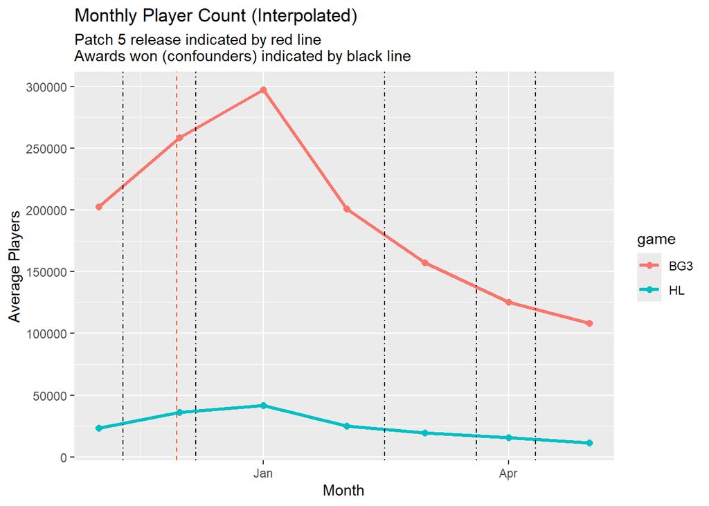

```r
# Plotting BG3 vs HL player counts with intervention markers
games_ts_plot <- games_df %>%
  ggplot(
  aes(x = month,
      y = avg_players,
      color = game
      )) +
  geom_line(linewidth = 1.1) +
  geom_vline(
    xintercept = bg3_patch5_date,
    color = "orangered",
    linetype = "dashed") +
  geom_point(size = 2, na.rm = TRUE) +
  geom_vline(
    xintercept = as.Date(c("2023-11-10", "2023-12-07", "2024-02-15", "2024-03-20","2024-04-11")),
    color = "black",
    linetype = "dotdash") +
  labs(title = "Monthly Player Count (Interpolated)",
       subtitle = "Patch 5 release indicated by red line\nAwards won (confounders) indicated by black line",
       x = "Month",
       y = "Average Players") +
       scale_y_continuous(breaks = seq(0,300000, by = 50000))
games_ts_plot
```